# sklearn.datasets.fetch_20newsgroups

**sklearn.datasets.fetch_20newsgroups(*, *data_home=None*, *subset='train'*, *categories=None*, *shuffle=True*, *random_state=42*, *remove=()*, *download_if_missing=True*, *return_X_y=False*)[[source]](https://github.com/scikit-learn/scikit-learn/blob/f3f51f9b6/sklearn/datasets/_twenty_newsgroups.py#L152)**

Load the filenames and data from the 20 newsgroups dataset (classification).

Download it if necessary.

| Classes | 20 |
| --- | --- |
| Samples total | 18846 |
| Dimensionality | 1 |
| Features | text |

Read more in the [User Guide](https://scikit-learn.org/1.1/datasets/real_world.html#newsgroups-dataset).

**Parameters:**

**data_home**str, default=None**

Specify a download and cache folder for the datasets. If None, all scikit-learn data is stored in ‘~/scikit_learn_data’ subfolders.

**subset**{‘train’, ‘test’, ‘all’}, default=’train’**

Select the dataset to load: ‘train’ for the training set, ‘test’ for the test set, ‘all’ for both, with shuffled ordering.

**categories**array-like, dtype=str, default=None**

If None (default), load all the categories. If not None, list of category names to load (other categories ignored).

**shuffle**bool, default=True**

Whether or not to shuffle the data: might be important for models that make the assumption that the samples are independent and identically distributed (i.i.d.), such as stochastic gradient descent.

Determines random number generation for dataset shuffling. Pass an int for reproducible output across multiple function calls. See [Glossary](https://scikit-learn.org/1.1/glossary.html#term-random_state).

**remove**tuple, default=()**

May contain any subset of (‘headers’, ‘footers’, ‘quotes’). Each of these are kinds of text that will be detected and removed from the newsgroup posts, preventing classifiers from overfitting on metadata.

‘headers’ removes newsgroup headers, ‘footers’ removes blocks at the ends of posts that look like signatures, and ‘quotes’ removes lines that appear to be quoting another post.

‘headers’ follows an exact standard; the other filters are not always correct.

**download_if_missing**bool, default=True**

If False, raise an IOError if the data is not locally available instead of trying to download the data from the source site.

**return_X_y**bool, default=False**

If True, returns `(data.data, data.target)` instead of a Bunch object.

New in version 0.22.

**Returns:**

**bunch**`Bunch`**

Dictionary-like object, with the following attributes.

**datalist of shape (n_samples,)**

The data list to learn.

**target: ndarray of shape (n_samples,)**

The target labels.

**filenames: list of shape (n_samples,)**

The path to the location of the data.

**DESCR: str**

The full description of the dataset.

**target_names: list of shape (n_classes,)**

The names of target classes.

**(data, target)**tuple if `return_X_y=True`**

A tuple of two ndarrays. The first contains a 2D array of shape (n_samples, n_classes) with each row representing one sample and each column representing the features. The second array of shape (n_samples,) contains the target samples.

New in version 0.22.

## Examples using `sklearn.datasets.fetch_20newsgroups`

Biclustering documents with the Spectral Co-clustering algorithm

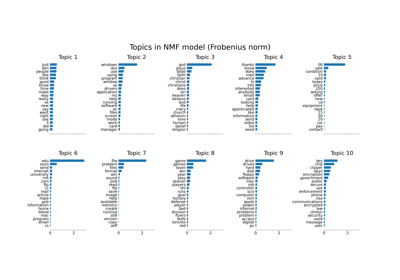

Topic extraction with Non-negative Matrix Factorization and Latent Dirichlet Allocation

Sample pipeline for text feature extraction and evaluation

Column Transformer with Heterogeneous Data Sources

Semi-supervised Classification on a Text Dataset

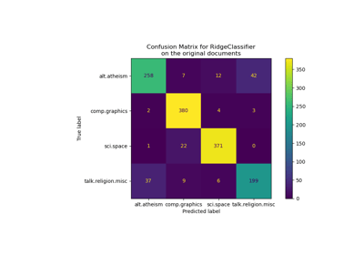

Classification of text documents using sparse features

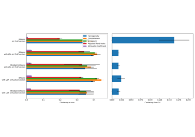

Clustering text documents using k-means

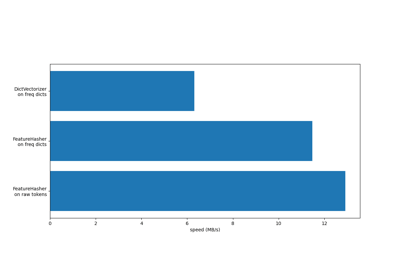

FeatureHasher and DictVectorizer Comparison

© 2007–2022 The scikit-learn developers  
Licensed under the 3-clause BSD License.  
https://scikit-learn.org/1.1/modules/generated/sklearn.datasets.fetch_20newsgroups.html